# Real Estate Prediction Model

Simranh Kaur Bhasin

11/04/2020

The following program demonstrates the implementation of a Linear Regression Model on a real estate dataset. It includes the date of purchase, house age, location, distance to nearest MRT station, and house price of unit area. The model is applied in an attempt to estimate and further predict the price per unit area of the property based on attributes that show maximum correlation with it.

We begin by reading the data.

```r
library("caret")
```

```r
library("ggplot2")
library("GGally")

setwd("/home/simranh/Desktop/DataSc")
mydata=read.csv(file="real_estate.csv", header=TRUE)

rs_data=data.frame(mydata)
head(rs_data)
```

```
##   No transaction_date house_age distance_to_the_nearest_MRT_station
## 1  1         2012.917      32.0                            84.87882
## 2  2         2012.917      19.5                           306.59470
## 3  3         2013.583      13.3                           561.98450
## 4  4         2013.500      13.3                           561.98450
## 5  5         2012.833       5.0                           390.56840
## 6  6         2012.667       7.1                          2175.03000
##   number_of_convenience_stores latitude longitude house_price_of_unit_area
## 1                           10 24.98298  121.5402                     37.9
## 2                            9 24.98034  121.5395                     42.2
## 3                            5 24.98746  121.5439                     47.3
## 4                            5 24.98746  121.5439                     54.8
## 5                            5 24.97937  121.5425                     43.1
## 6                            3 24.96305  121.5125                     32.1
```

```r
any(is.na(rs_data))
```

```
## [1] FALSE
```

```r
any(is.character(rs_data))
```

```
## [1] FALSE
```

```r
summary(rs_data)
```

```
##        No      transaction_date   house_age
##  Min.   :  1   Min.   :2013     Min.   : 0.00
##  1st Qu.:104   1st Qu.:2013     1st Qu.: 9.10
##  Median :207   Median :2013     Median :16.10
##  Mean   :207   Mean   :2013     Mean   :17.74
##  3rd Qu.:310   3rd Qu.:2013     3rd Qu.:28.20
##  Max.   :413   Max.   :2014     Max.   :43.80
##  distance_to_the_nearest_MRT_station number_of_convenience_stores
##  Min.   :  23.38                     Min.   : 0.000
##  1st Qu.: 289.32                     1st Qu.: 1.000
##  Median : 492.23                     Median : 4.000
##  Mean   :1086.29                     Mean   : 4.082
##  3rd Qu.:1455.80                     3rd Qu.: 6.000
##  Max.   :6488.02                     Max.   :10.000
##     latitude       longitude     house_price_of_unit_area
##  Min.   :24.93   Min.   :121.5   Min.   :  7.60
##  1st Qu.:24.96   1st Qu.:121.5   1st Qu.: 27.70
##  Median :24.97   Median :121.5   Median : 38.40
##  Mean   :24.97   Mean   :121.5   Mean   : 37.92
##  3rd Qu.:24.98   3rd Qu.:121.5   3rd Qu.: 46.60
##  Max.   :25.01   Max.   :121.6   Max.   :117.50
```

It can be seen that our data is not categorical (it is thus numerical) and doesn’t contain any missing values or inconsistencies.

Now,the ggpairs() function from the GGally package is used to create a plot matrix to see how the predictor and response variables relate to one another and do some exploratory data visualization.This will enable us to decide if a prediction model can be built or not.

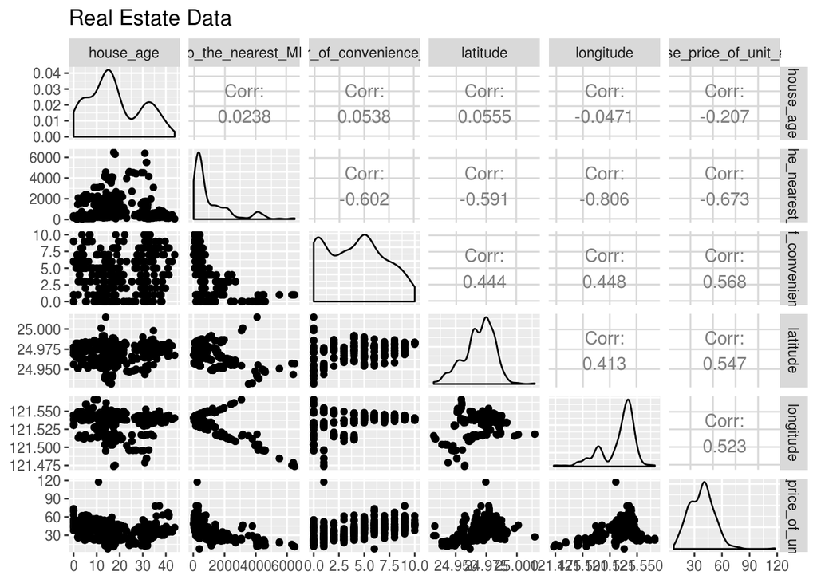

```r
ggpairs(data=rs_data, columns = 3:8, title="Real Estate Data")
```

First let us do some exploratory data analysis for these four attributes by plotting histograms to judge the data distribution.To visualize the median of the observations we will be plotting the line for their respective medians as well.

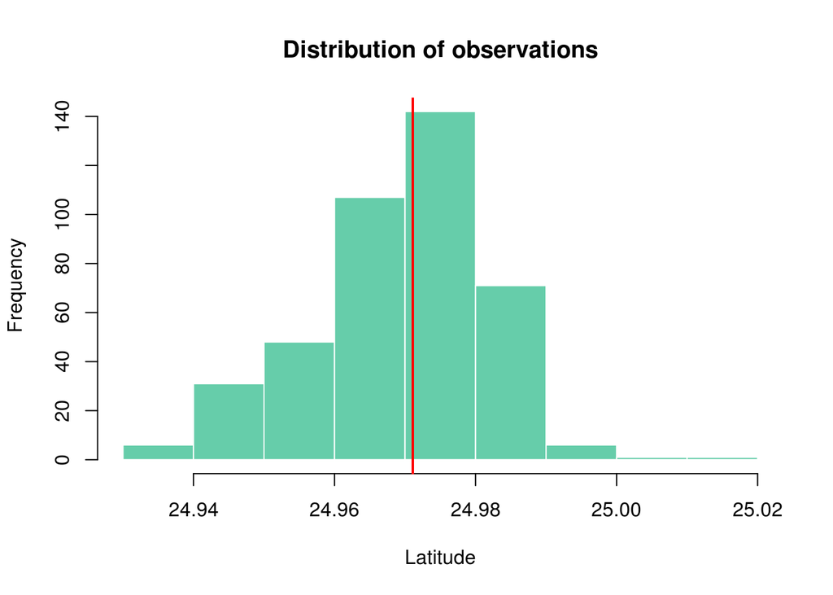

```r
hist(Latitd, main="Distribution of observations", xlab="Latitude", col="aquamarine3", border="white")
abline(v=med.Lat, col="red", lwd=2)
```

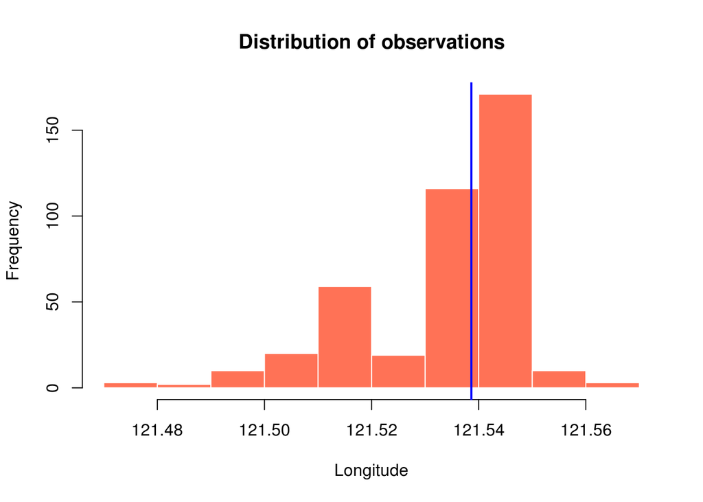

```r
hist(Longtd, main="Distribution of observations", xlab="Longitude", col="coral1", border="white")
abline(v=med.Long, col="blue", lwd=2)
```

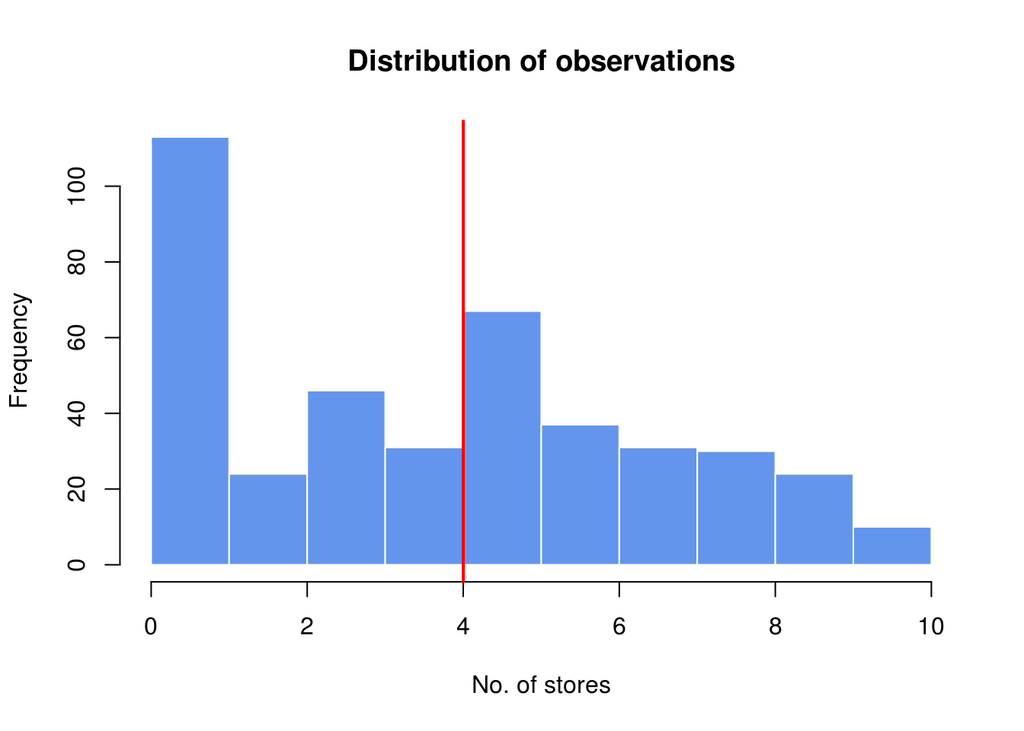

```r
hist(no.conv.stores, main="Distribution of observations", xlab="No. of stores", col="cornflowerblue", border="white")
abline(v=med.conv, col="red", lwd=2)
```

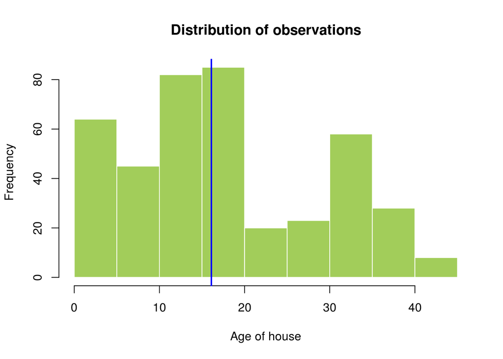

```r
hist(HouseAge, main="Distribution of observations", xlab="Age of house", col="darkolivegreen3", border="white")
abline(v=med.age, col="blue", lwd=2)
```

Now to fit our linear model to the scatterplot of the predictor variables, ggplot() will be used.

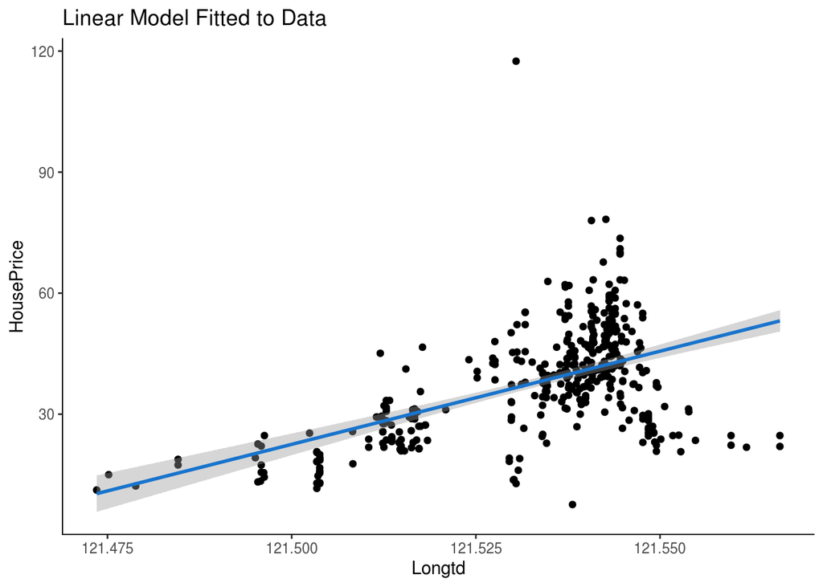

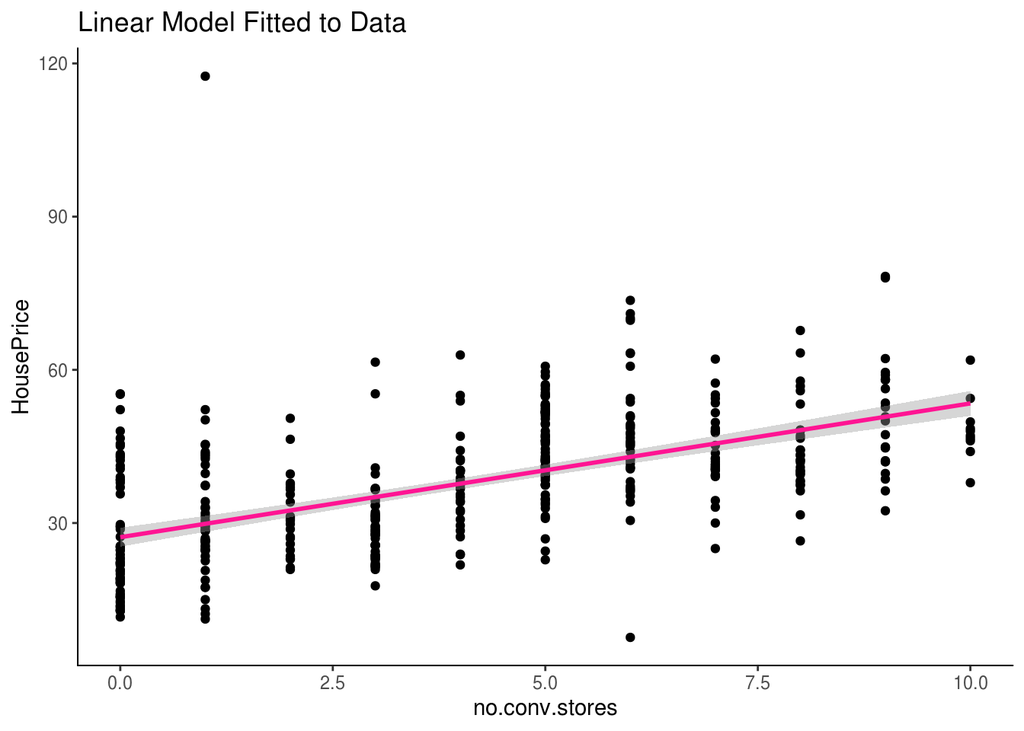

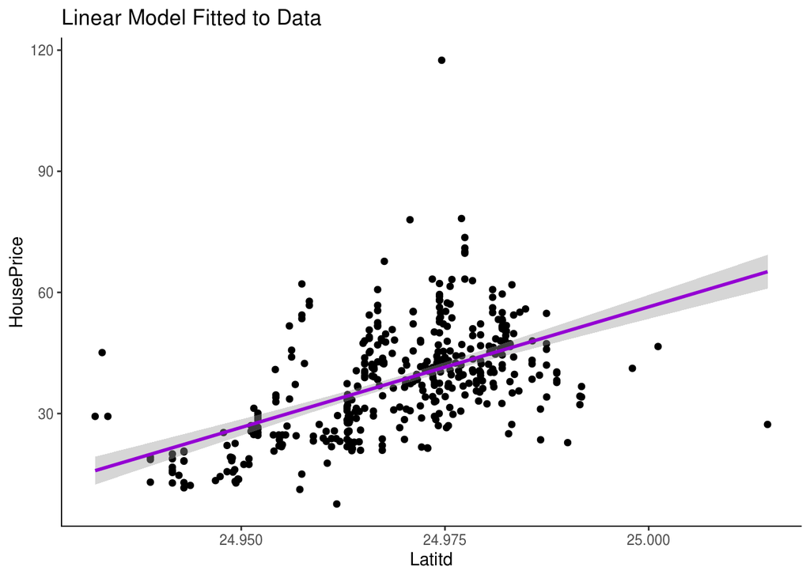

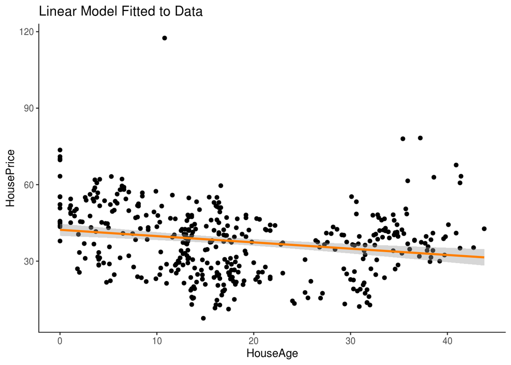

The plots show that a very apparent linear relationship doesn’t exist between the predictor and response variables and thus we will require polynomial regression in order to fit our model more accurately to our data while also avoiding overfitting.

Further, the dataset is split into 2 sets, traning set that includes 70% of the original data and testing set that contains the remaining 30%. The training set is used to train the model and the testing set will help in cross-validating the model.

```r
trainIndex=createDataPartition(rs_data$No, p=0.7,list=FALSE)
training=rs_data[trainIndex,]
testing=rs_data[-trainIndex,]
```

Thus, now the training set can be modelled as:-

```r
linearMod=lm(HousePrice ~ I(Longtd^2) +  I(Latitd^3) + I(no.conv.stores^5) + HouseAge, data=training)
```

The attributes have been alotted specific degrees so as to fit the model more accurately to the training data.

The plots depict similarity between the predicted values and the original ones.

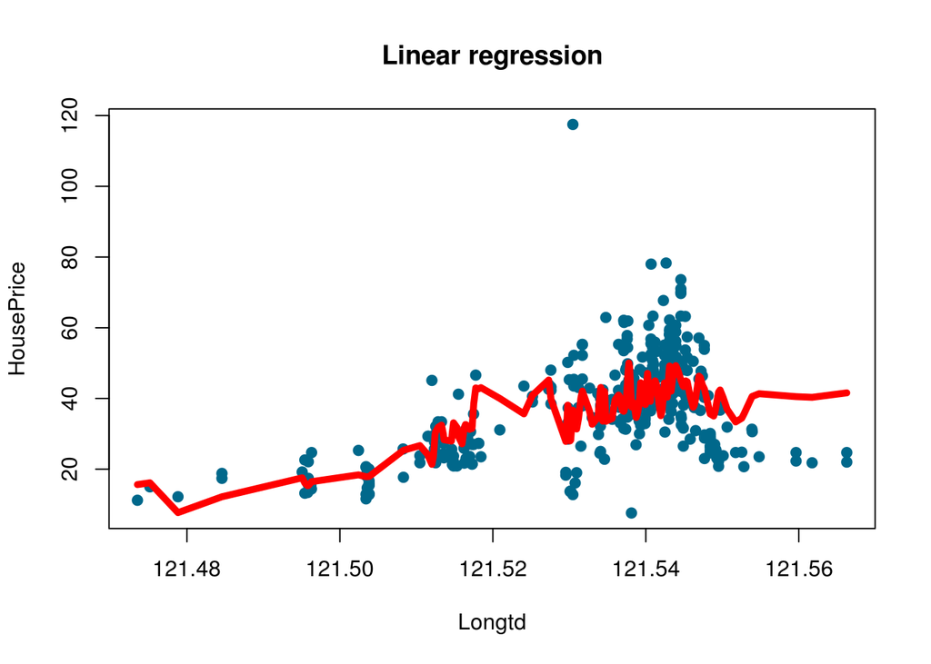

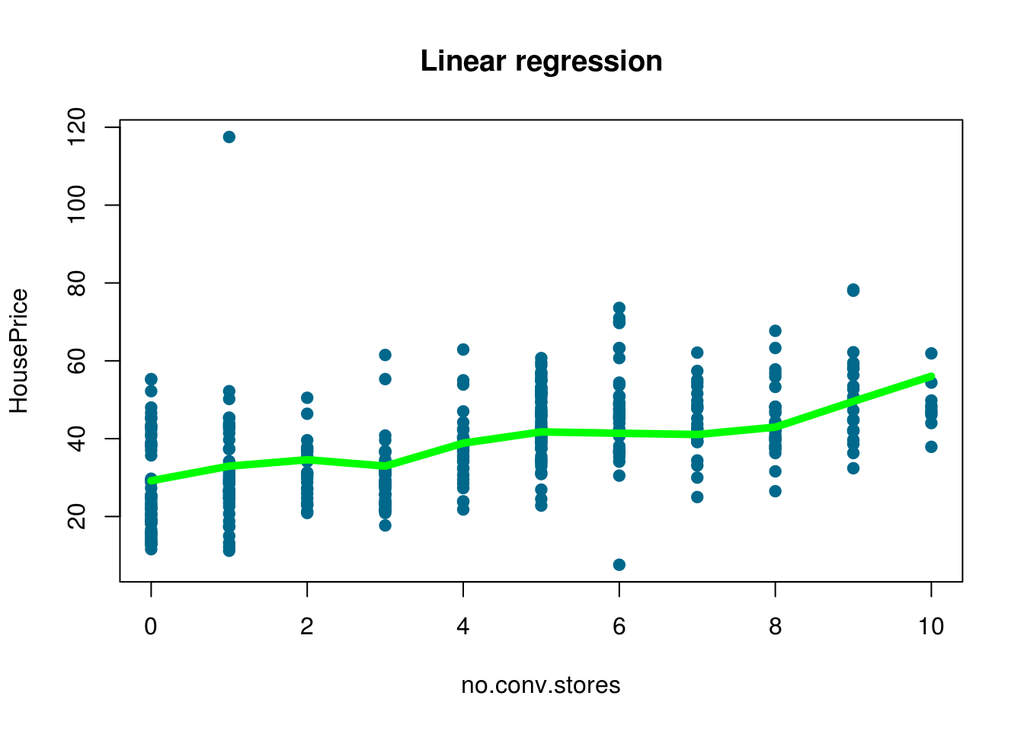

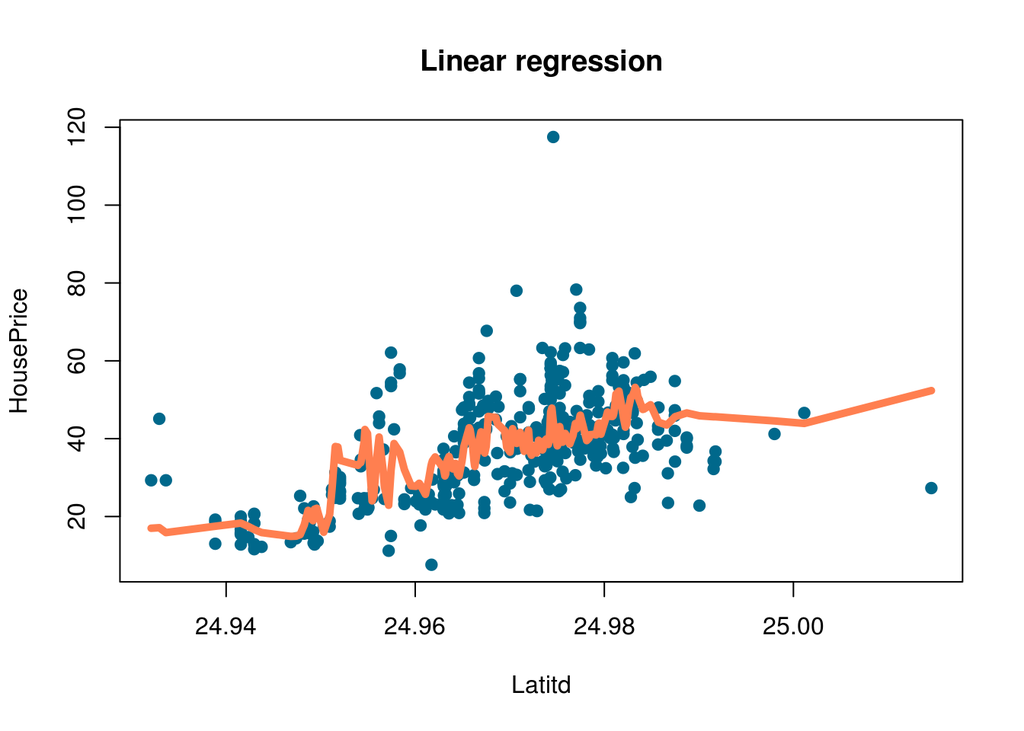

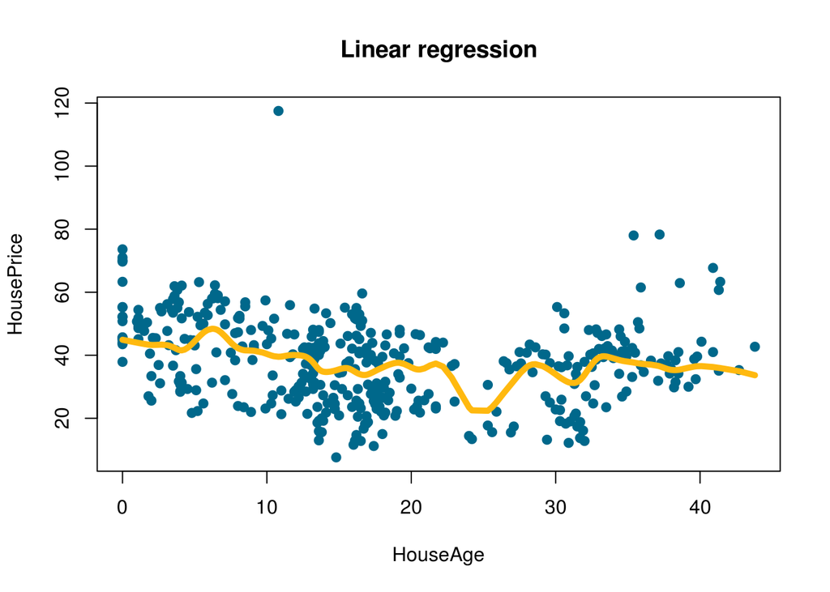

Now the linear model is built and the summary statistics will demonstrate the statistical significance of the model.

```r
summary(linearMod)
```

[output not shown]

The model’s p-Value and the p-Value of individual predictor variables are very important because, we can consider a linear model to be statistically significant only when both these p-Values are less than the pre-determined statistical significance level, which is ideally 0.05. This is visually interpreted by the significance stars. Since all the variables that have been considered have three stars beside them, it can be said that they are all significant.

The summary of the residuals indicates how well our model fits to our data. Generally, it is required that the residuals be normally distributed around zero. This can be visualized through the histogram made using ggplot2. The histogram below exhibits a good distribution of residuals around zero.

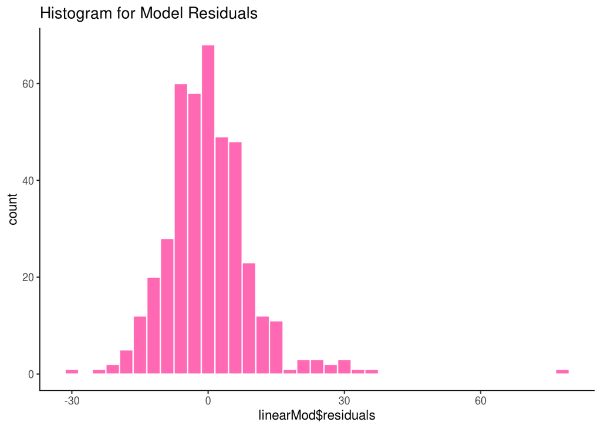

```r
ggplot(data=rs_data,aes(linearMod$residuals))+
geom_histogram(binwidth=3,color="white", fill="hotpink")+
theme(panel.background = element_rect(fill = "white"),
axis.line.x=element_line(),
axis.line.y=element_line()) +
ggtitle("Histogram for Model Residuals")
```

Further the model thus built will be utilized to predict the dependent variable on the test data.

```r
pred=predict(linearMod,testing)
head(pred)
```

[output not shown]

This way, the model will give predicted values for 30% of the original data that was in the testing dataframe.

Now the accuracy measures (like min_max accuracy) and error rates (MAPE or MSE) will be calculated.This will indicate the prediction accuracy of the model.

To calculate the accuracy, a dataframe is made that consists of the actual and the predicted values of the House price per unit area.

```r
actual_pred=data.frame(cbind(actuals=testing$house_price_of_unit_area,predicteds=pred))
min_max_accuracy= mean(apply(actual_pred,1,min)/apply(actual_pred,1,max))
min_max_accuracy
```

```
## [1] 0.732066
```

```r
MAPE=mean(abs((actual_pred$predicteds - actual_pred$actuals)) / actual_pred$actuals)
MAPE    #mean absolute percentage error
```

```
## [1] 0.3640408
```